# A1 - OVB simulation

Andrew Dickinson

Winter 2020

> Due date: 12 January 2020

> Please have your simulation ready to share in class on Tuesday.

**When people make the claim that *correlation does not imply causation*, they usually mean that the existence of some correlation between $y$ and $x_1$ does not imply that variation in $x_1$ *causes* variation in $y$.**

- That is, they tend to be acknowledging that you can have correlation without causation

**Assignment: Propose and simulate a data-generating process in which (**i**) causation runs from $x_1$ to $y$ but at the same time (**ii**) the correlation of $y$ and $x_1$ is zero. Write it in an Rmd file and make the argument visually.**

- *Yes, at the end of this you should have simulated something (good) and demonstrated that the lack of correlation does not imply lack of causation (which is like a party trick).*

## Sim I

I want to propose and simulate a data generating process in which: - causation from $x_1$ to $y$ - the correlation of $y$ and $x_1$ is zero

I simulate the DGP with the following function:

```r
# Set up function for a single iteration
sim1_iter = function(n = 1000) {
  # Generate data
  dgp_it = tibble(
    u = runif(n, -5, 5),
    e = rnorm(n, mean = 0, sd = 1),
    f = rnorm(n, mean = 0, sd = 1),
    w = (rnorm(n, mean = 5, sd = 1))^2,
    x1 = 1 + exp(0.01*w) + e,
    x2 = 1 + 2.5*x1 + f,
    y = 5*x1 - 2*x2 + u
  )
  # Collect estimates from regressions with and without OV
  bind_rows(
    lm(y ~ x1, data = dgp_it) %>% broom::tidy() %>% filter(term == "x1"),
    lm(y ~ x1 + x2, data = dgp_it) %>% broom::tidy() %>% filter(term == "x1"),
  ) %>% mutate(model = c("x2 is unobserved", "x2 is observed"))
}
```

Then simulating the function `sim1_iter()` 500 times with the following process:

```r
# Set up the parallelization
plan(multiprocess, workers = 8, .progress = T)
invisible(future_options(seed = 1234))
# Run the simulation
sim1_df = future_map_dfr(rep(15, 500), sim1_iter)
```

And I plot the resulting dataframe with `ggplot2`

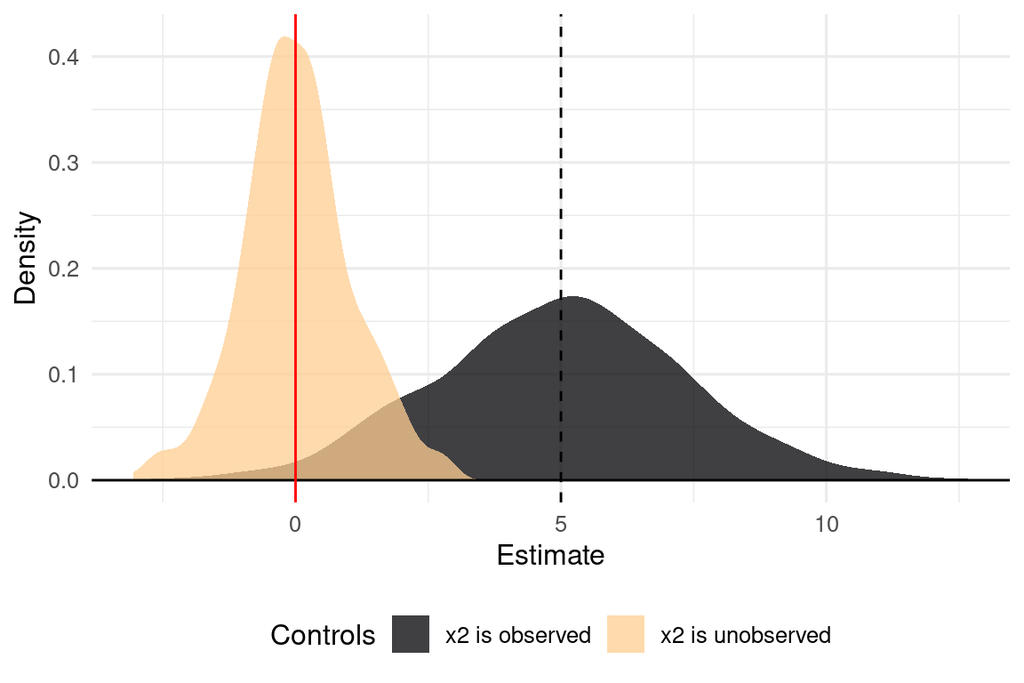

```r
# Plot simulation density plots
ggplot(data = sim1_df, aes(x = estimate, fill = model)) +
  geom_density(color = NA, alpha = 0.75) +
  geom_hline(yintercept = 0) +
  geom_vline(xintercept = 5, linetype = "dashed") +
  geom_vline(xintercept = 0, colour = "red") +
  labs(x = "Estimate", y = "Density") +
  scale_fill_viridis_d("Controls", option = "magma", end = 0.9) +
  theme_minimal(base_size = 12) +
  theme(legend.position = "bottom")
```

## Sim II - Potential outcome framework

In my second simulation I write a DGP in a potential outcomes framework with a binary treatment variable $D_i$ and an outcome variable $Y_i$

I define my DGP as follows:

$$\begin{align*}
Y_{0i} &= X_i + u_i \\
Y_{1i} &= Y_{0i} + W_i + v_i \\
D_i &= \mathbb{I}(X_i + \varepsilon_i < 8) \\
Y_i &= Y_{0i} + D_i \tau_i \\
\end{align*}$$

where

$$\begin{align*}
u_i &\sim U(-5, 5) \\
v_i &\sim U(-3, 3) \\
\varepsilon_i &\sim U(-1, 1) \\
X_i &\sim N(10, 3) \\
W_i &\sim N(5, 1) \\
\end{align*}$$

```r
# Set up function for a single iteration
sim2_iter = function(n = 1000) {
  # Generate data
  dgp_it = tibble(
    u = runif(n, -5, 5),
    v = runif(n, -3, 3),
    e = runif(n, -1, 1),
    x = rnorm(n, mean = 10, sd = 3),
    w = rnorm(n, mean = 5, sd = 1),
    y0 = x + u,
    y1 = y0 + w + v,
    t = y1 - y0,
    d = (x + e < 8) %>% as.numeric(),
    y = y0 + d * t
  )
  # Collect estimates from regressions with and without OV
  bind_rows(
    lm(y ~ d, data = dgp_it) %>% broom::tidy() %>% filter(term == "d"),
    lm(y ~ d + x, data = dgp_it) %>% broom::tidy() %>% filter(term == "d"),
  ) %>% mutate(model = c("x is unobserved", "x is observed"))
}
```

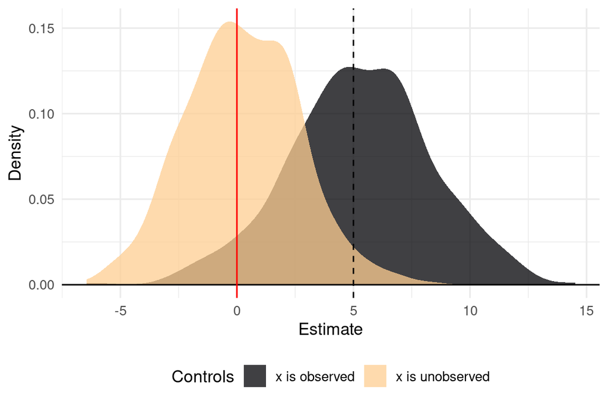

```r
# Plot simulation density plots
ggplot(data = sim2_df, aes(x = estimate, fill = model)) +
  geom_density(color = NA, alpha = 0.75) +
  geom_hline(yintercept = 0) +
  geom_vline(xintercept = 5, linetype = "dashed") +
  geom_vline(xintercept = 0, colour = "red") +
  labs(x = "Estimate", y = "Density") +
  scale_fill_viridis_d("Controls", option = "magma", end = 0.9) +
  theme_minimal(base_size = 12) +
  theme(legend.position = "bottom")
```